# Mavenを使った外部ライブラリの利用

> オブジェクト指向プログラミングおよび演習1 補足資料

## 前提知識としてのJavaビルドツール

プログラミング言語には大抵の場合、ソースコードをビルドする際に必要なライブラリファイルを管理するツールや、設定情報を一括管理したりするためのビルドツールと呼ばれるものがあります。

これらのビルドツールは、基本的な動作についてはほぼ同じで、ライブラリの取得方法や、設定ファイルの書き方が異なっていたりします。 この資料で紹介するのは、Mavenについてのみです。 ですが、GradleはAndroidアプリ開発でよく使用されるビルドツールですし、作成するアプリケーションによってビルドツールを何にするか、という点も昨今の開発には必須の作業になります。

## Maven

Mavenはプロジェクトをビルドする際に、ビルドに必要な依存ライブラリをインターネットから取得して自身のプロジェクトに組み込む形式を採っています。 もちろん、インターネットからライブラリをダウンロードする関係上、インターネットに接続している状態でビルドを行う必要があります。 ｓ プロジェクトで使用するライブラリを依存ライブラリといいます。 依存ライブラリは、`POM.xml`と言う名前のXMLファイル内の`dependencies`の項目によって管理されており、それをメンテナンスすれば、必要なライブラリをわざわざ自分でダウンロードしてプロジェクトに読み込みさせる必要はありません。

この資料では、とりあえずMavenでプロジェクトを作り、依存関係を確認、ビルドして実行までを確認します。

### Mavenのインストール

Mavenは、IntelliJ IDEAで開発を行う場合は、IntelliJ IDEA内部に含まれていますので別途インストールする必要はありません。

もしIDEを使用しないで別途インストールする必要がある方は、以下のリンク先からダウンロードできます。（この講義で最初にインストールしたSDKManからでもダウンロードとインストールが可能です。）

- [Maven – Download Apache Maven](https://maven.apache.org/download.cgi)

# ビルドツールにMavenを指定してプロジェクトを作る

Mavenのプロジェクトサンプルとして、microservicesフレームワークのsparkを使ってみましょう。  
(※クラスタコンピューティングフレームワークにApache Sparkというものがありますが、そちらではなくJava/Kotlin用のラムダ構文対応Webフレームワークのsparkです。)

- [Spark Framework: An expressive web framework for Kotlin and Java](http://sparkjava.com/)

## プロジェクトの作成

ビルドシステムをMavenに変えてプロジェクトを作成します。

[figure not shown]

ビルドシステムを変えると、ビルドシステムに沿ったプロジェクトが生成されます。Mavenの場合は、IntelliJ IDEAと比べてソースコードファイルの保存場所が若干変わります。

## 依存ライブラリを設定

プロジェクトが作成されたら、`POM.xml`を開きます。

依存関係にSparkを追加します。

参考にする資料は以下のリンク先です。

- [Documentation - Spark Framework: An expressive web framework for Kotlin and Java](http://sparkjava.com/documentation#getting-started)

`pom.xml`の`<project>`タグ内の直下に以下の依存関係を追加しましょう。

```xml
    <dependencies>
        <dependency>
            <groupId>com.sparkjava</groupId>
            <artifactId>spark-core</artifactId>
            <version>2.9.3</version>
        </dependency>
    </dependencies>
```

保存したら、依存ライブラリのダウンロードのためにMavenプロジェクトの再ロードを行います。 以下の画像を参考に、`pom.xml`を右クリック→`Maven`→`プロジェクトの再ロード`を選択し、少し待ちます。

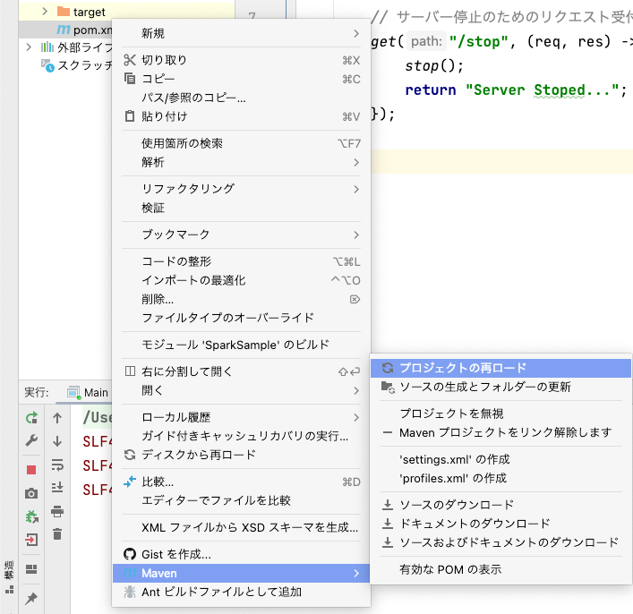

また、「ソースコードおよびドキュメントのダウンロード」を選ぶと、プロジェクト内にライブラリだけでなく中身のソースコードやJavaDocまでダウンロードが可能です。 ライブラリのバグに当たってしまった場合は、ライブラリ内のソースコードが必要になることがありますので、適宜使ってください。

## コードを書く

作成されたパッケージ以下に、通常のJavaクラス`Main.java`を作成し、以下のコードを貼り付けます。

```java
import static spark.Spark.*;

public class Main {
    public static void main(String[] args) {
        get("/hello", (req, res) -> "Hello World");

        // サーバー停止のためのリクエスト受付
        get("/stop", (req, res) -> {
          stop();
          return "Server Stoped...";
        });
    }
}
```

## 動作確認

`Main.java`をメインクラスとして、プロジェクトを実行します。

Loggingライブラリが正常に読み込みできないエラーが以下のように出ますが、実行自体は成功しているはずです。

```bash
SLF4J: Failed to load class "org.slf4j.impl.StaticLoggerBinder".
SLF4J: Defaulting to no-operation (NOP) logger implementation
SLF4J: See http://www.slf4j.org/codes.html#StaticLoggerBinder
```

このエラーを回避するには、以下の依存ライブラリをpom.xmlに追記します。

```xml
        <dependency>
            <groupId>org.slf4j</groupId>
            <artifactId>slf4j-simple</artifactId>
            <version>1.7.21</version>
        </dependency>
```

Logger関連でエラーが出ていても実行できているはずなので、以下のURLにアクセスして、Hello Worldが表示されるかを確認します。

http://localhost:4567/hello

## サーバーの停止

Sparkで作成したサーバーは、基本的に起動したらそのまま起動したままになります。  
サーバーを停止するためには、`stop()`メソッドを呼ばなければサーバーを停止できません。（プロセスごと落とすとJavaVMも道連れになりかねないです）

↑のサンプルソースでは、`stop()`を呼ぶための処理も追加しています。  
（クライアントがわからサーバー停止できるコードなので、本来は使っちゃダメなコードです。）

下のURLにアクセスしてサーバーを停止しましょう。

http://localhost:4567/stop

※コードを書き換えてビルドして実行する場合に、サーバー停止しないとポート番号が使えないため実行できません。

## Mavenの依存ライブラリについて

この資料では、Webアプリケーション用のライブラリを紹介していますが、ファイル処理の時に紹介している`apache-commons-csv`や`opencsv`なども同様、簡単にライブラリを追加できます。

- [Commons CSV – Home](https://commons.apache.org/proper/commons-csv/)
- [opencsv –](http://opencsv.sourceforge.net/)

ライブラリの配布サイトを見ると、dependencyのXML記述があるはずです。 これを探してPOM.xmlに記述するだけで、インターネットからライブラリをダウンロードしてくれます。 通常のプロジェクト作成では、ライブラリを使用したい場合に以下の手順が発生します。

1. 使いたい外部ライブラリのjarファイルをダウンロード
2. プロジェクトディレクトリに配置
3. そのjarファイルに対してクラスパス設定

こういった手順を廃止できるだけでも間違いが発生しづらくなり、安心して外部ライブラリが使えます。 チーム開発を行う場合でも、プロジェクトディレクトリとpom.xmlを共有できれば事前に使用するライブラリを統一することができるなどのメリットしかありません。

## Oracleの開発しているmicroservicesフレームワーク

また、別のMavenプロジェクトの始め方として、Archetypeを使用する方法も紹介しておきます。

参考にOracleの開発しているWebと連携するアプリ作成時のバックエンドとなりえるmicroservicesフレームワークである「Helidon」を使ってみましょう。

- [Helidon](https://helidon.io/#/)

IntelliJ IDEAの新規プロジェクトの画面にて、「Maven Archetype」を選び、以下の画像を参考にプロジェクトを作成します。

Helidonには、SEとMPがあり、それぞれ以下のような説明があります。

- SE : Java SEのリアクティブストリーム、非同期プログラミング、関数型プログラミング、フルエントスタイルAPIを包含するコンパクトなツールキットです
- MP : Jakarta EEコミュニティがポータブルな方法でマイクロサービスを実行できるようにするためのEclipse MicroProfileランタイムです

どちらでもよいのですが、コードの書き方が大きく異なるため、どちらも試してみましょう。 この資料では、Archetypeに「io.helidon.archetypes:helidon-quickstart-se」を選んでいます。

[figure not shown]

プロジェクトを作成し終えたら、依存関係のライブラリをインターネットから読み込む手順が自動的に始まり、それが終わるとプロジェクトのソースコードなどを読めたり変更を加えたりできるようになります。

また、初回のビルドの際に、`POM.xml`に記載されたすべてのライブラリをダウンロードする手順が自動的に始まりますので、とにかく時間が掛かります。  
（**講義内でみんなが一斉に行うと、インターネットアクセスが集中してしまい予期せぬ不具合が発生しかねません。お家に帰ってから試しましょう。**）

### 動作確認

`Main.java`をメインクラスとして実行します。

起動したら、`GreetService.java`のコメントにあるように動作確認ができます。

`curl`コマンドを使うとコマンドラインからHTTPのリクエストが投げられますが、ここではいったん、以下のURLにアクセスしてみてください。

http://localhost:8080/greet/Joe

```
{"message":"Hello Joe!"}
```

上記のようなJSONデータが表示されます。

このJSONデータは、プロジェクトの`Main.java`や`GreetService.java`で生成されていますので、どこでそのデータが生成されているかソースコードを調べてみましょう。

これを使うことで、ネットワーク上にAPIを持たせることができ、アプリ作成時にも活用できるようになります。 こういったフレームワークは他にもたくさんありますが、詳細な説明は割愛します。

# ライブラリの探し方

Googleなどの検索エンジンで、「`Java ライブラリ 〇〇`」〇〇にやりたいことを書いて調べてみましょう。

ライブラリの名前がわかったら、以下のサイトでMavenリポジトリの存在を確認します。見つからなければ、jarファイルをダウンロードするしかないのではないかと思われます。

- [The Central Repository Search Engine](https://search.maven.org/)

あとは、ライブラリの公式ドキュメントをよく読み、やりたいことを実現できるように頑張ってください。